# Diffusion ellipsoids (tensor imaging)

The basic ideas of diffusion tensor imaging are connected to the visualization of ellipses. We calculate and plot some key images for the diffusion imaging models. The goal is to give you some intuitions.

## Contents

- Set up the eigenvalues
- Add an axis
- Save it as a png file in the current directory
- Build a diffusion tensor from a simple 6-direction encoding scheme.
- Compute the surfaces
- Render the surfaces
- Drawing the ellipsoid that correspond with the ADC measurements (Tony)
- Draw the ellipsoid that corresponds with the covariance matrix of the
- Putting the ADC measurement points onto the ellipsoid
- Set up multiple contributors
- Plot the ADC values for Q1
- We plot the values on representing the diffusion distance this way

## Set up the eigenvalues

The three axes of an ellipse can each have their own length. We set up an ellipse with two axes of length 1 and one axis of length 3.

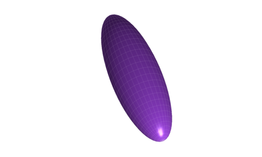

```matlab
center = [1,1,1];
ev = [1 1 3];
nFaces = 32;

% Render an ellipsoid with specified eigenvalues
[px, py, pz] = ellipsoid(center(1),center(2),center(3),ev(1),ev(2),ev(3),nFaces);

% The ellipsoid points are px,py,pz.  Don't ask me why the order is
% changed to x,z,y.
surf(px,pz,py,'EdgeAlpha',0.2,'EdgeColor',[1 1 1],'FaceColor',[0.7 0.3 1]);

% Light the surface and show it
camlight; lighting phong; material shiny;
set(gca, 'Projection', 'perspective');
axis equal vis3d off;
view(-20,60);
set(gcf,'Position',[400 30 600 600]);
% whitebg(gcf,'white')
```

## Add an axis

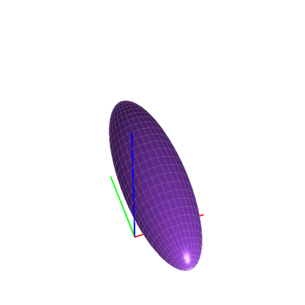

```matlab
axLen = ev.*2+.2; hold on;
line([0;axLen(1)],[0;0],[0;0],'Color','r','LineWidth',2);
line([0;0],[0;axLen(2)],[0;0],'Color','g','LineWidth',2);
line([0;0],[0;0],[0;axLen(3)],'Color','b','LineWidth',2);
hold off;
```

## Save it as a png file in the current directory

```matlab
mrUtilPrintFigure('ellipsoid.png',gcf,0);
disp('Saved as ellipsoid.png in current dir');
```

```
Saved as ellipsoid.png in current dir
```

[figure not shown]

## Build a diffusion tensor from a simple 6-direction encoding scheme.

By using 6 directions, we guarantee that the tensor will perfectly fit the data. (But the code below will work for any number of directions.)

```matlab
bvecs = [1,1,0; 1,0,1; 0,1,1; -1,1,0; -1,0,1; 0,-1,1];

% Make sure bvecs are unit vectors
bvecs = bvecs./repmat(sqrt(sum(bvecs.^2,2)),1,3);
adc = [1 2 3 1 2 1];

% Solve for the diffusion tensor D:
m = [bvecs(:,1).^2 bvecs(:,2).^2 bvecs(:,3).^2 2*bvecs(:,1).*bvecs(:,2) 2*bvecs(:,1).*bvecs(:,3) 2*bvecs(:,2).*bvecs(:,3)];
coef = pinv(m)*adc';
D = [coef(1) coef(4) coef(5); coef(4) coef(2) coef(6); coef(5) coef(6) coef(3)];

% Confirm that D can accurately predict the ADC data
pAdc = zeros(1,length(adc));
for ii=1:length(adc)
  pAdc(ii) = bvecs(ii,:)*D*bvecs(ii,:)';
end
fprintf('max diff between ADC and predicetd ADC: %g\n',max(abs(pAdc-adc)));
```

```
max diff between ADC and predicetd ADC: 4.44089e-16
```

## Compute the surfaces

```matlab
[x,y,z] = sphere(32);
sz = size(x);
u = [x(:), y(:), z(:)];

[vec,val] = eig(D);

dirADC = diag(adc)*bvecs;
```

The probability that a spin at the origin will move to position v at time t given diffusion tensor D is:

p_x = 1./sqrt(det(D)*(4*pi*t).^3) * exp(-(v*D-1*v')./(4*t));

Using the diffusion tensor to transform the unit sphere coords produces an ellipsoid, even if there are non-zero off-diagonals in D.

```matlab
clear e
e{1} = u*D;

% We use D to predict ADC values for each direction.
%
% Scaling the unit sphere points by the predicted ADC produces a
% peanut. This is the proper way to predicted ADC profile. This is clear
% when we render the surface along with the original ADC values.
sphAdc = zeros(1,size(u,1));
for ii=1:size(u,1)
    sphAdc(ii) = u(ii,:)*D*u(ii,:)';
end
% scale the unit vectors by the predicted ADC for each vector
e{2} = diag(sphAdc)*u;
```

Using the eigenvalue decomposition also produces an ellipsoid. This ellipsoid DOES NOT represent the predicted ADC profile. Rather, it represents the RMS diffusion distance of spins that began at the center of the voxel. Note that this surface will accurately predict the ADC values that happen to fall exactly on one of the three axes of the ellipsoid. (They'd better, since the eigenvalues are taken as the ADC's along the three axes of the ellipsoid.) This surface does not, however, predict the ADC profile.

```matlab
e{3} = u*sqrt(2*val)*vec';
```

## Render the surfaces

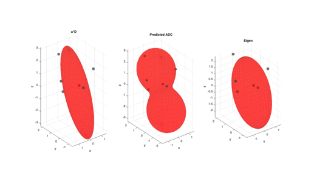

```matlab
figure;
titles = {'u*D','Predicted ADC','Eigen'};
cmap = [autumn(255); [.25 .25 .25]];
for ii=1:length(e)
    subplot(1,length(e),ii);
    x = reshape(e{ii}(:,1),sz); y = reshape(e{ii}(:,2),sz); z = reshape(e{ii}(:,3),sz);
    surf(x,y,z,'EdgeAlpha',0.1);
    hold on;
    for jj=1:length(adc)
        [px py pz] = ellipsoid(dirADC(jj,1),dirADC(jj,2),dirADC(jj,3),.1,.1,.1,8);
        surf(px,py,pz,repmat(256,size(pz)),'EdgeAlpha',0);
    end
    hold off;
    axis equal vis3d; colormap(cmap); alpha 0.5;
    title(titles{ii});
    xlabel('x');ylabel('y');zlabel('z');
end
```

## Drawing the ellipsoid that correspond with the ADC measurements (Tony)

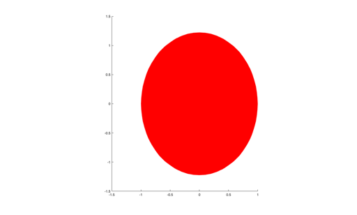

```matlab
[xmesh, ymesh, zmesh] = meshgrid(-3:0.1:3,-3:0.1:3,-3:0.1:3);

% Make the ellipsoid mesh
vmesh = coef(1)*xmesh.^2 + coef(2)*ymesh.^2 + ...
    coef(3)*zmesh.^2 + coef(4)*2*xmesh.*ymesh + coef(5)*2*xmesh.*zmesh + coef(6)*2*ymesh.*zmesh;

figure;
p = patch(isosurface(xmesh,ymesh,zmesh,vmesh,1));
isonormals(xmesh,ymesh,zmesh,vmesh,p)
set(p,'FaceColor','red','EdgeColor','none','EdgeAlpha',0.1);%
daspect([1 1 1])
hold on;
```

## Draw the ellipsoid that corresponds with the covariance matrix of the

gaussian pdf on the water molecule movement

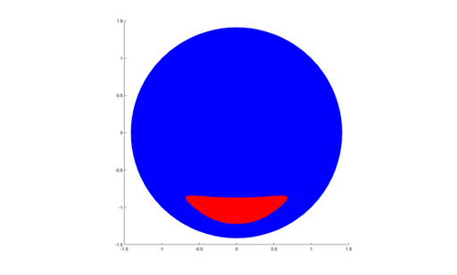

```matlab
[U S V] = svd(D);
Dinv = U*diag(1./diag(2*S))*V';
coef_inv = [Dinv(1,1) Dinv(2,2) Dinv(3,3) Dinv(1,2) Dinv(1,3) Dinv(2,3)];
vmesh = coef_inv(1)*xmesh.^2 + coef_inv(2)*ymesh.^2 + coef_inv(3)*zmesh.^2 + coef_inv(4)*2*xmesh.*ymesh + coef_inv(5)*2*xmesh.*zmesh + coef_inv(6)*2*ymesh.*zmesh;
p = patch(isosurface(xmesh,ymesh,zmesh,vmesh,1));
isonormals(xmesh,ymesh,zmesh,vmesh,p)
set(p,'FaceColor','blue','EdgeColor','none','EdgeAlpha',0.1);%
daspect([1 1 1])
```

## Putting the ADC measurement points onto the ellipsoid

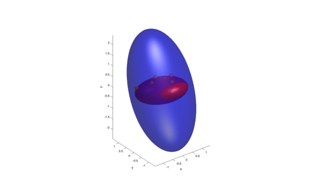

```matlab
dirADC = diag(1./sqrt(adc))*bvecs;
for jj=1:length(adc)
    [px, py, pz] = ellipsoid(dirADC(jj,1),dirADC(jj,2),dirADC(jj,3),.1,.1,.1,8);
    surf(px,py,pz,repmat(256,size(pz)),'EdgeAlpha',0);
end

hold off;
view(3);
camlight
lighting gouraud
axis equal vis3d; colormap(cmap); alpha 0.5;
xlabel('x');ylabel('y');zlabel('z');
```

## Set up multiple contributors

```matlab
% Illustrative
[x,y,z] = sphere(16);
grad_dirs = [x(:),y(:),z(:)];
x(1) = 0.3;
x(2) = .3*10^9;

% Make two different orientations
fibredir = [1,1,0]';
fibredir = fibredir/norm(fibredir);
ev1 = [1 .3 .3];
[u s v] = svd(fibredir);
Q1 = u*diag((1./ev1).^2)*u';

% Make two different orientations
fibredir = [0,1,1]';
fibredir = fibredir/norm(fibredir);
[u s v] = svd(fibredir);
Q2 = u*diag((1./ev1).^2)*u';
```

## Plot the ADC values for Q1

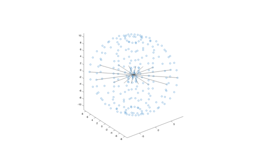

```matlab
% Given a tensor, Q1, we calculate the ADC in a particular direction this
% way:
s = grad_dirs*Q1*grad_dirs';
s = diag(s);

% To show the size of the ADC in the gradient direction, we plot the size
grad_dirs_s = zeros(size(grad_dirs));
for ii=1:size(grad_dirs,1)
    grad_dirs_s(ii,:) = grad_dirs(ii,:)*s(ii);
end
grad_dirs_s2 = [grad_dirs_s; -grad_dirs_s];

figure;
plot3(grad_dirs_s2(:,1),grad_dirs_s2(:,2),grad_dirs_s2(:,3),'o')
axis equal

patch(grad_dirs_s2(:,1),grad_dirs_s2(:,2),grad_dirs_s2(:,3))
```

## We plot the values on representing the diffusion distance this way

```matlab
% These are the 3D points that solve 1 = grad_dirs' * Q1 * grad_dirs
[xmesh, ymesh, zmesh] = meshgrid(-3:0.1:3,-3:0.1:3,-3:0.1:3);
% D = [coef(1) coef(4) coef(5); coef(4) coef(2) coef(6); coef(5) coef(6) coef(3)];
coef1 = [Q1(1,1) Q1(2,2) Q1(3,3) Q1(1,2) Q1(1,3) Q1(2,3)];
vmesh1 = coef1(1)*xmesh.^2 + coef1(2)*ymesh.^2 + ...
    coef1(3)*zmesh.^2 + coef1(4)*2*xmesh.*ymesh + coef1(5)*2*xmesh.*zmesh + coef1(6)*2*ymesh.*zmesh;

coef2 = [Q2(1,1) Q2(2,2) Q2(3,3) Q2(1,2) Q2(1,3) Q2(2,3)];
vmesh2 = coef2(1)*xmesh.^2 + coef2(2)*ymesh.^2 + ...
    coef2(3)*zmesh.^2 + coef2(4)*2*xmesh.*ymesh + coef2(5)*2*xmesh.*zmesh + coef2(6)*2*ymesh.*zmesh;


figure;
p = patch(isosurface(xmesh,ymesh,zmesh,vmesh1,1));
isonormals(xmesh,ymesh,zmesh,vmesh1,p)
% daspect([1 1 1])
colormap(jet);
%set(p,'FaceColor',[0 .3 .6],'EdgeAlpha',0.2,'EdgeColor',[0 0 0]);
set(p,'FaceColor','b','EdgeAlpha',0.2,'EdgeColor',[0 0 0]);
daspect([1 1 1])

camlight;
lighting phong;
material shiny;

set(gca, 'Projection', 'perspective');
axis off
whitebg(gcf,'white')

p = patch(isosurface(xmesh,ymesh,zmesh,vmesh2,1));
isonormals(xmesh,ymesh,zmesh,vmesh2,p)
daspect([1 1 1])
set(p,'FaceColor','g','EdgeAlpha',0.2,'EdgeColor',[0 0 0]);
alpha 0.5
axis off
grid on
```

[output not shown]

[output not shown]

```matlab
view(3);
camlight
lighting gouraud
axis equal vis3d;
colormap(cmap);
alpha 0.5;
xlabel('x');ylabel('y');zlabel('z');

camlight;
lighting gouraud; material shiny;
set(gca, 'Projection', 'perspective');
axis equal vis3d on; colormap(copper);
% whitebg(gcf,'white')
grid on

% dirADC = diag(1./sqrt(adc))*bvecs;
% for jj=1:length(adc)
%     [px py pz] = ellipsoid(dirADC(jj,1),dirADC(jj,2),dirADC(jj,3),.1,.1,.1,8);
%     surf(px,py,pz,repmat(256,size(pz)),'EdgeAlpha',0);
% end

f=x(1);
dPar=x(2);
dPerp=dPar*(1-f);

% Radial wavenumbers
% GAMMA = 2.675987E8;
% modQ = GAMMA*smalldel.*G;
% modQ_Sq = modQ.^2;

modQ_Sq = 1;

% Synthesize measurements from model
%l_q=length(grad_dirs);
cosTheta = grad_dirs*fibredir(:);
cosThetaSq = cosTheta.^2;
% difftime = (delta-smalldel/3);
difftime = 1;
E = exp(-difftime.*modQ_Sq.*((dPar - dPerp)*cosThetaSq + dPerp));

% Ligt it and show it
camlight;
lighting phong; material shiny;
set(gca, 'Projection', 'perspective');
axis equal vis3d off; colormap(copper);
view(-20,60);
set(gcf,'Position',[400 30 600 600]);
whitebg(gcf,'white');
```

[Published with MATLAB® R2026a](https://www.mathworks.com/products/matlab/)